# CoDA log-ratio representations for single cell RNA-seq data using CoDAschd

2024.09.10

This tutorial introduces how to use CoDAschd package to perform CoDA log-ratio transformations for single cell RNA-seq data matrix. Besides, we demonstrated how to incorporate the CoDA transformed data with current downstream tools and analyses.

load CoDAschd package

```r
library(CoDAschd)
```

load other packages

```r
library(patchwork)
library(ggplot2)
library(easyCODA)
library(coda.base)
library(Seurat)
library(data.table)
library(MatrixCorrelation)
library(ggpubr)
library(scran)
library(igraph)
library(slingshot)
library(RColorBrewer)
```

# Implementation

## Read data

We used a small dataset cellbench-cellmix3 (https://doi.org/10.1038/s41592-019-0425-8 and https://doi.org/10.1186/s13059-020-02132-x) with three cell lines for demonstration.

```r
# read data
raw_dat <- fread("cellbench_cellmix3_genebycell.txt",sep="\t",header=TRUE,stringsAsFactors=FALSE)
raw_dat <- as.matrix(raw_dat,rownames=1)
rownames(raw_dat) <- gsub("_","-",rownames(raw_dat))

metadat <- read.csv("cellmix3.metadata.csv",header=TRUE,stringsAsFactors=FALSE,row.names=1)
metadat$celltype_f <- factor(metadat$celltype_c,levels=c("H2228","H1975","HCC827"))
```

## Run various CoDA LR transformations

```r
# CLR (s/gm(s) based)(default);
# other 'countAdd' options included s/max,s/10000,user-defined number(e.g.,1 or 0.1)
# other 'method' options inlcuded IQLR,LVHA,ILR,mdCLR,manual(user specified genes);groupIQLR,groupLVHA
clr_sgms <- runCoDAschd_CountAdd(raw_dat,countAdd="s/gm",method="CLR")

# CLR (s/10000 based);
clr_s10000 <- runCoDAschd_CountAdd(raw_dat,countAdd="s/10000",method="CLR")

# LogNorm CLR(prior-log-normalized(scale factor=10000) approximation)
# The scale factor=10000 used in LogNorm CLR was suggested in Seurat LogNorm implementation.
# set log_normalized=TRUE if input data has already been log-normalized (e.g., Seurat/scanpy log-normalization)
clr_lognorm <- runCoDAschd_LogNorm(raw_dat,method="CLR",log_normalized=FALSE)

# Seurat LogNorm
raw_lognorm <- CreateSeuratObject(counts=raw_dat,meta.data=metadat,min.cells=0,min.features=0)
raw_lognorm <- NormalizeData(raw_lognorm)
raw_lognorm <- as.matrix(raw_lognorm@assays$RNA@data)
```

Example output

```r
# Raw count
raw_dat[c("GAPDH","UBC","ACTB"),1:3]
```

```
#>       H1975_H2228_HCC827.7_0_2.1 H1975_H2228_HCC827.0_0_9.2
#> GAPDH                         63                        159
#> UBC                            8                         14
#> ACTB                          55                        129
#>       H1975_H2228_HCC827.0_0_9.3
#> GAPDH                        191
#> UBC                           23
#> ACTB                         139
```

```r
# CLR(s/gm(s))
clr_sgms[c("GAPDH","UBC","ACTB"),1:3]
```

```
#>       H1975_H2228_HCC827.7_0_2.1 H1975_H2228_HCC827.0_0_9.2
#> GAPDH                   5.125906                   5.531412
#> UBC                     2.323737                   2.218559
#> ACTB                    4.933920                   5.234377
#>       H1975_H2228_HCC827.0_0_9.3
#> GAPDH                   5.762370
#> UBC                     2.826724
#> ACTB                    5.310179
```

```r
# CLR(s/10000
clr_s10000[c("GAPDH","UBC","ACTB"),1:3]
```

```
#>       H1975_H2228_HCC827.7_0_2.1 H1975_H2228_HCC827.0_0_9.2
#> GAPDH                   5.073799                   5.481112
#> UBC                     2.279629                   2.177051
#> ACTB                    4.882004                   5.184303
#>       H1975_H2228_HCC827.0_0_9.3
#> GAPDH                   5.712198
#> UBC                     2.782104
#> ACTB                    5.260315
```

```r
# CLR(LogNorm with scale factor=10000)
clr_lognorm[c("GAPDH","UBC","ACTB"),1:3]
```

```
#>       H1975_H2228_HCC827.7_0_2.1 H1975_H2228_HCC827.0_0_9.2
#> GAPDH                   5.073799                   5.481112
#> UBC                     2.279629                   2.177051
#> ACTB                    4.882004                   5.184303
#>       H1975_H2228_HCC827.0_0_9.3
#> GAPDH                   5.712198
#> UBC                     2.782104
#> ACTB                    5.260315
```

```r
# Raw LogNorm
raw_lognorm[c("GAPDH","UBC","ACTB"),1:3]
```

```
#>       H1975_H2228_HCC827.7_0_2.1 H1975_H2228_HCC827.0_0_9.2
#> GAPDH                   3.927943                   4.235682
#> UBC                     1.991172                   1.945482
#> ACTB                    3.795001                   4.029950
#>       H1975_H2228_HCC827.0_0_9.3
#> GAPDH                   4.401091
#> UBC                     2.370104
#> ACTB                    4.087869
```

```r
# similarities between clr_s10000 and clr_lognorm
sum(clr_s10000==clr_lognorm)/(nrow(clr_lognorm)*ncol(clr_lognorm)) #~0.05; clr_s10000 and clr_lognorm are similar but not exactly the same
```

```
#> [1] 0.05136977
```

## Matrix similarites between CLR (s/10000 based) and CLR (LogNorm based with scale factor=10000)

CLR (s/10000 based) and CLR (LogNorm based with scale factor=10000) are very similar to each other but not totally same.

```r
# RMSE
# clr_lognorm-clr_s10000
sqrt(mean((clr_lognorm-clr_s10000)^2))
```

```
#> [1] 7.933462e-16
```

```r
# clr_lognorm-clr_sgms
sqrt(mean((clr_lognorm-clr_sgms)^2))
```

```
#> [1] 0.021782
```

```r
# clr_lognorm-raw_lognorm
sqrt(mean((clr_lognorm-raw_lognorm)^2))
```

```
#> [1] 0.4874293
```

# Example downstream analyses

The CoDA transformed scRNA-seq matrix is easily to be incorporated with other popular downstream analyses. Here we applied two of them as examples.

## Dimension reduction-partial SVD(or Fast Truncated SVD) and Clustering

We first performed dimension reduction using partial SVD followed by clustering on this dataset with differentiation trajectories, before starting conducting trajectory inference.

Write a function for convenience

```r
getCluster <- function(x,meta,npc=10,cent=3){

    tmp <- CreateSeuratObject(counts=x,meta.data=meta,min.cells=0,min.features=0)
    tmp <- FindVariableFeatures(tmp,nfeatures=3000,verbose=FALSE)
    tmp <- ScaleData(tmp,verbose=FALSE)
    tmp <- RunPCA(tmp,verbose=FALSE) # Partial SVD / Fast Truncated SVD

    # K-means
    tmp$kmeans <- kmeans(tmp@reductions$pca@cell.embeddings[,1:npc],centers=cent)$cluster
    # Louvain
    tmpgraph <- buildSNNGraph(tmp@reductions$pca@cell.embeddings[,1:npc],transposed=T,k=10,d=NA)
    res <- cluster_louvain(tmpgraph)$membership
    cc <- aggregate(tmp@reductions$pca@cell.embeddings[,1:npc],list(res),mean)
    cc <- as.matrix(cc[,-1])
    hclu <- hclust(dist(cc))
    clu <- cutree(hclu,cent)
    clu <- clu[res]
    tmp$lv_clu <- clu
    # Seurat default
    tmp <- FindNeighbors(tmp,dims=1:npc,verbose=FALSE)
    tmp <- FindClusters(tmp,verbose=FALSE)

    tmp <- RunUMAP(tmp,dims=1:npc,verbose=FALSE)
    return(tmp)
}
```

Get partial SVD, UMAP and clustering results

```r
# create list of transformed data
dat <- list(raw_lognorm=raw_lognorm,clr_sgms=clr_sgms,clr_s10000=clr_s10000,clr_lognorm=clr_lognorm)

# remove cells without enough information
dat <- lapply(dat,function(x) x[,rownames(metadat)])

# partial SVD + various clustering methods
datCluster <- lapply(dat,getCluster,metadat)
```

### 2-D PCA visualize cell line labels and clusters

```r
dat_pca_label <- list()
for(x in names(datCluster)){
    p <- DimPlot(datCluster[[x]],reduction="pca",group.by="celltype_c")+ggtitle(x)
    dat_pca_label[[x]] <- p
}

dat_pca_louvain <- list()
for(x in names(datCluster)){
    p <- DimPlot(datCluster[[x]],reduction="pca",group.by="lv_clu")+ggtitle(x)
    dat_pca_louvain[[x]] <- p
}
```

plots (cell line labels(upper) and Louvain clusters(lower))

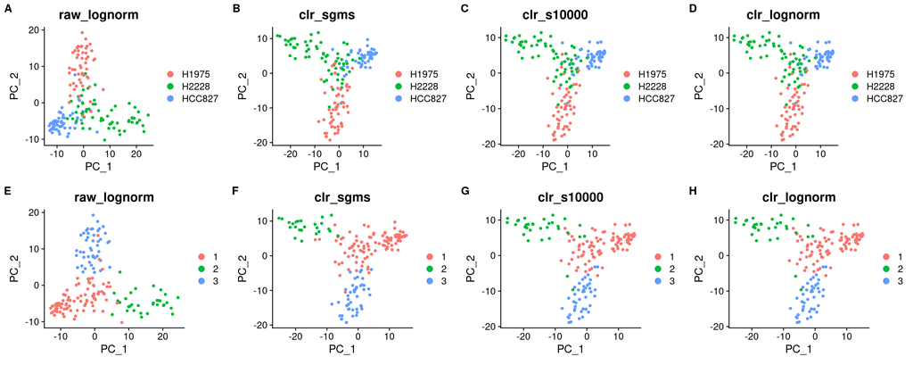

```r
dat_pca <- c(dat_pca_label,dat_pca_louvain)
ggarrange(plotlist=dat_pca,ncol=4,nrow=2,labels="AUTO")
```

### 2-D UMAP visualize cell line labels and clusters

```r
dat_umap_label <- list()
for(x in names(datCluster)){
    p <- DimPlot(datCluster[[x]],reduction="umap",group.by="celltype_c")+ggtitle(x)
    dat_umap_label[[x]] <- p
}

dat_umap_louvain <- list()
for(x in names(datCluster)){
    p <- DimPlot(datCluster[[x]],reduction="umap",group.by="lv_clu")+ggtitle(x)
    dat_umap_louvain[[x]] <- p
}
```

plots(cell line labels(upper) and Louvain clusters(lower))

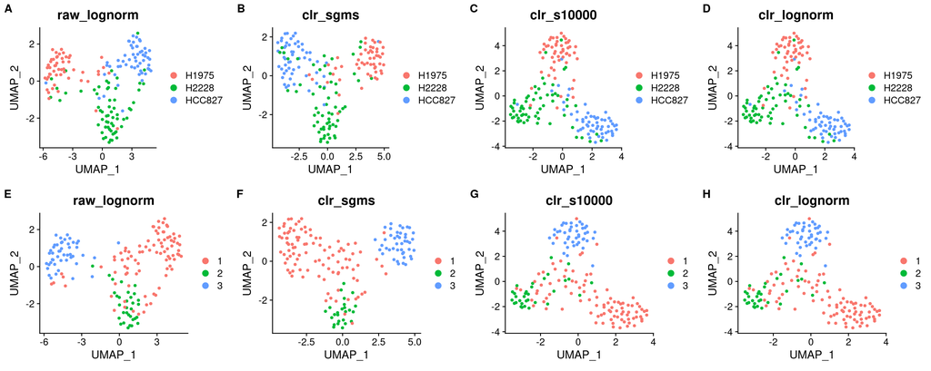

```r
dat_umap <- c(dat_umap_label,dat_umap_louvain)
ggarrange(plotlist=dat_umap,ncol=4,nrow=2,labels="AUTO")
```

As we use a differentiation trajectory dataset, cell types in 2-D projections are connected to each other, as expected.

## Trajectory inference with Slingshot

We used Slingshot as an example to perform trajectory inference with CoDA transformed scRNA-seq data

### Preprocessing

```r
# create list of transformed data
dat <- list(raw_lognorm=raw_lognorm,clr_sgms=clr_sgms,clr_s10000=clr_s10000,clr_lognorm=clr_lognorm)

# slingshot default processing
sce <- SingleCellExperiment(assays=List(counts=raw_dat))
FQnorm <- function(counts){
    rk <- apply(counts,2,rank,ties.method='min')
    counts.sort <- apply(counts,2,sort)
    refdist <- apply(counts.sort,1,median)
    norm <- apply(rk,2,function(r){ refdist[r] })
    rownames(norm) <- rownames(counts)
    return(norm)
}
assays(sce)$norm <- FQnorm(assays(sce)$counts)
sce <- log1p(assays(sce)$norm)
dat[["slingshot"]] <- sce

# remove cells without enough information
dat <- lapply(dat,function(x) x[,rownames(metadat)])
```

write some functions for convenience

```r
getSlingshot <- function(x,metad,startclu="0_9_0",endclu=NULL,scaling=TRUE){
    tmp <- SingleCellExperiment(assays=list(logcounts=as.matrix(x)),colData=metad)
    tmp_pca <- prcomp(t(assays(tmp)$logcounts),scale.=scaling) #already lognorm;here we scale the data
    reducedDims(tmp) <- SimpleList(PCA=tmp_pca$x[,1:2])
    tmp <- slingshot(tmp,clusterLabels='group',reducedDim='PCA',start.clus=startclu,end.clus=endclu)
    return(tmp)
}

evalSlingshot <- function(x,method="spearman",...){
    pt_col <- grep("slingPseudotime",colnames(colData(x)))
    lineages <- c(...)
    res <- c()
    for(y in lineages){
        # match the inferred trajectory with true lineage: determine by max overlaps of cells
        max_ovlp <- which.max(sapply(pt_col,function(z)
            sum(rownames(colData(x)[!is.na(colData(x)[,z]),])%in%rownames(colData(x)[!is.na(colData(x)[,y]),])) ))
        max_cor <- cor.test(colData(x)[,pt_col[max_ovlp]],colData(x)[,y],method=method)$estimate
        res <- c(res,max_cor)
    }
    names(res) <- lineages
    return(res)
}

plotTrajectory <- function(dataset,x,ng=3){
    tmpcolor <- brewer.pal(ng,'Set1')[dataset[[x]]$celltype_f]
    plot(reducedDims(dataset[[x]])$PCA,col=tmpcolor,asp=1,pch=16)
    lines(SlingshotDataSet(dataset[[x]]),lwd=2,type='lineages',col='black')
    legend("topright",legend=levels(dataset[[x]]$celltype_f),pch=19,col=brewer.pal(ng,'Set1')[factor(levels(dataset[[x]]$celltype_f))])
    title(main=x)
}
```

### Run Slingshot (set end point to c(“0_0_9”,“9_0_0”))

```r
res1_ss <- lapply(dat,getSlingshot,metadat,endclu=c("9_0_0","0_0_9"),scaling=TRUE)
```

Spearman correlation between predicted pseudotime and real time label

```r
res1_scc_ss <- as.data.frame(lapply(res1_ss,evalSlingshot,"spearman","H2228_to_H1975","H2228_to_HCC827"))
res1_scc_ss <- as.data.frame(t(res1_scc_ss))
res1_scc_ss
```

|  | H2228_to_H1975 | H2228_to_HCC827 |
| --- | --- | --- |
| raw_lognorm | 0.8547661 | 0.8778124 |
| clr_sgms | 0.9314544 | 0.9334574 |
| clr_s10000 | 0.9309082 | 0.9321259 |
| clr_lognorm | 0.9309082 | 0.9321259 |
| slingshot | 0.8543072 | 0.8891959 |

2-D PCA plots

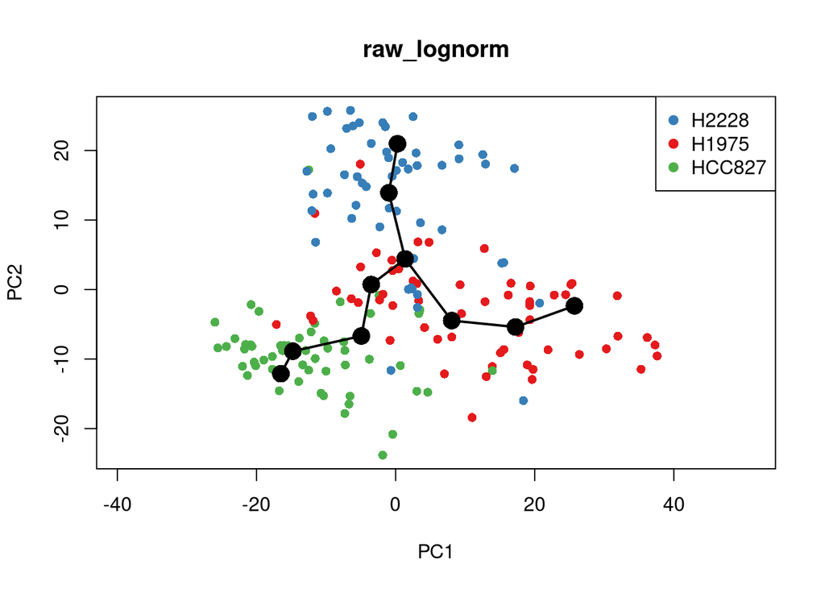

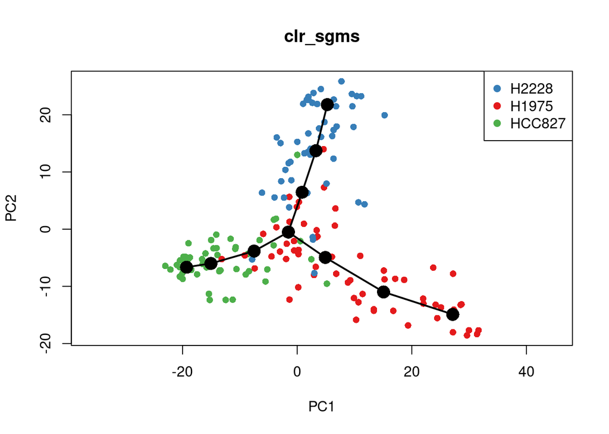

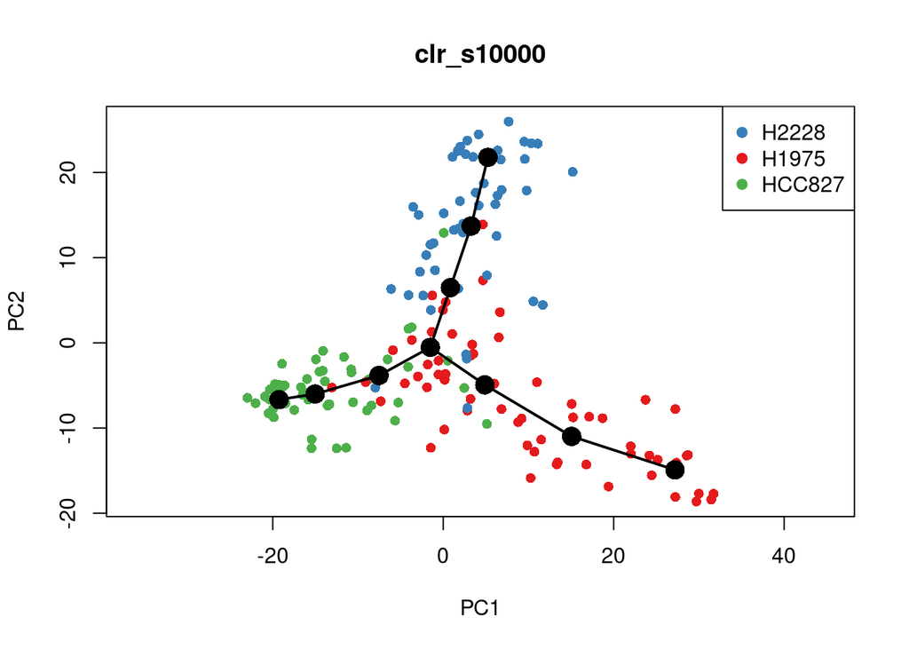

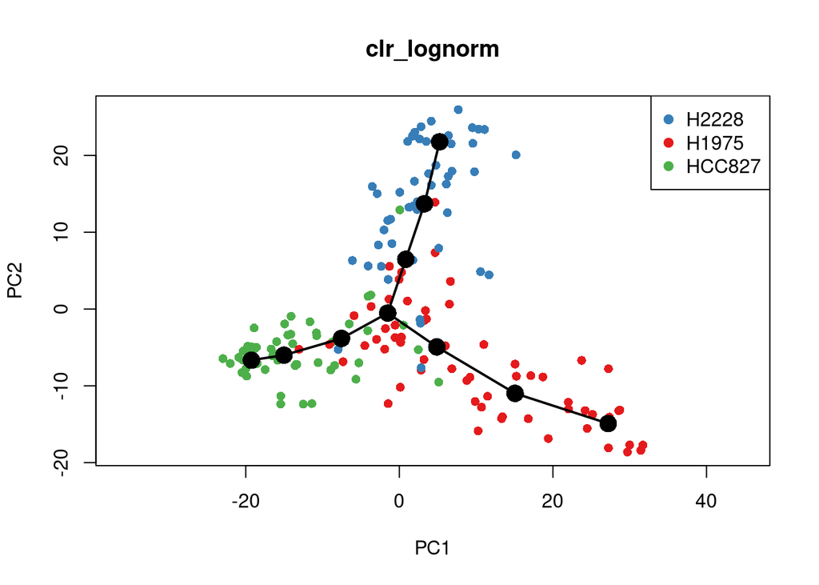

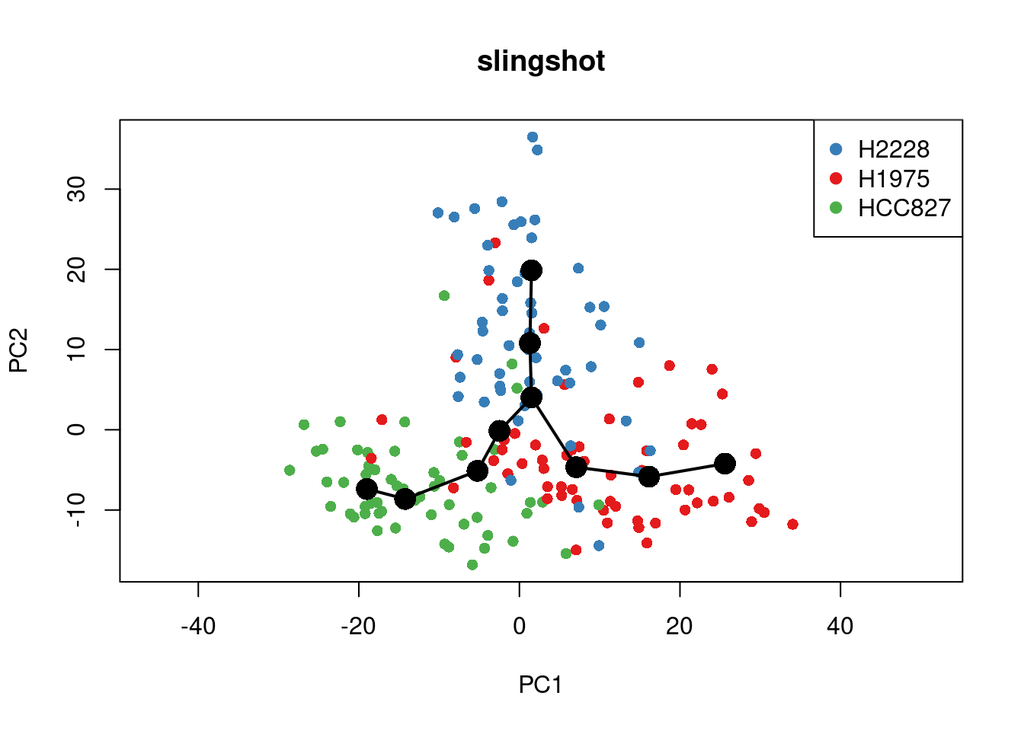

```r
for(x in names(res1_ss)){
    plotTrajectory(res1_ss,x)
}
```

Similarly, the analysis of CoDA transformed scRNA-seq matrix can be easily extended to other downstream applications, e.g., biomarker identification, differential expression analysis, SCENIC regulatory network.